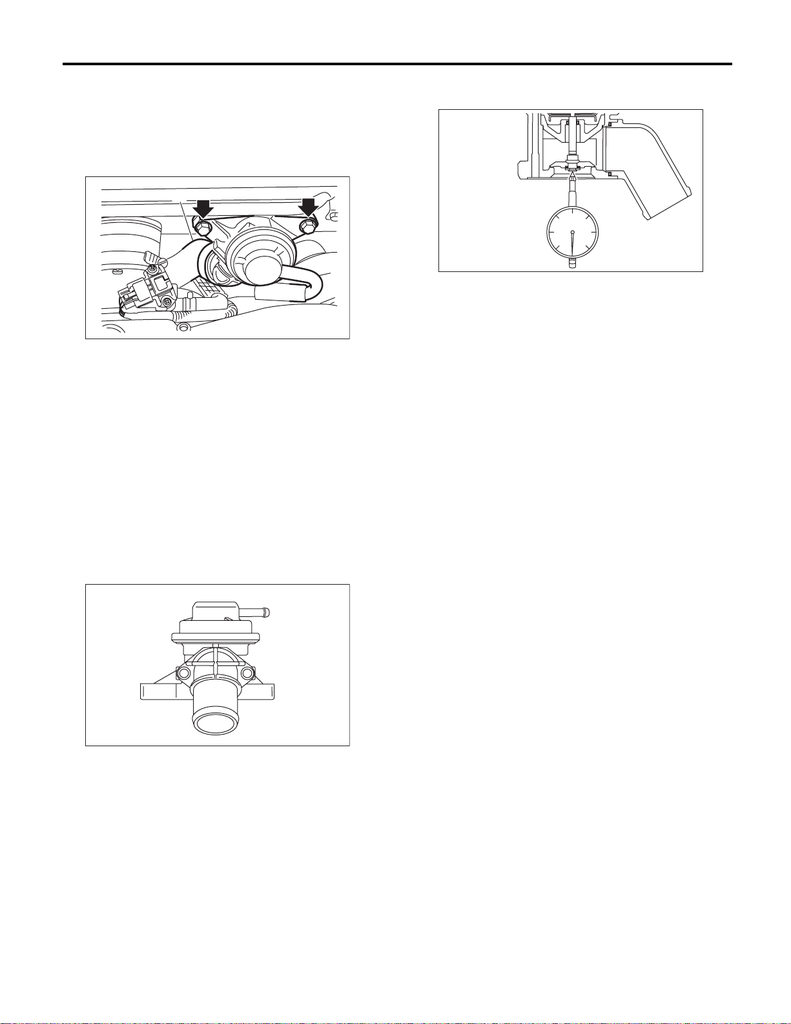

IN(STI)-20

Air By-pass Valve

INTAKE (INDUCTION)

8. Air By-pass Valve

A: REMOVAL

Remove the air by-pass valve from the intercooler,

and then disconnect air by-pass hose (A) and vac-

uum hose (B) from the air by-pass valve.

B: INSTALLATION

Install in the reverse order of removal.

NOTE:

Use a new gasket.

Tightening torque:

16 N·m (1.6 kgf-m, 11.8 ft-lb)

C: INSPECTION

1. AIR BY-PASS VALVE

1) Check that the air by-pass valve has no defor-

mation, cracks or other damages.

2) Connect the Mighty Vac to the nipple (A) of the

air by-pass valve.

3) Using the Mighty Vac, generate the vacuum

pressure to –93.3 kPa (–0.95 kg/cm

2

, –13.5 psi).

Check that the Mighty Vac gauge needle indication

holds 10 seconds without dropping down to lower

than –92.6 kPa (–0.94 kg/cm

2

, –13.4 psi).

4) Set a dial gauge to the end of valve rod of the air

by-pass valve.

5) Slowly generate vacuum pressure with the

Mighty Vac and check the pressure when the nee-

dle of the dial gauge (valve stroke) becomes 0.5

mm (0.02 in). If it is not within the standard, replace

the air by-pass valve.

Opening pressure (valve stroke 0.5 mm (0.02

in)):

Standard

–62.7 — –70.7 kPa (–0.64 — –0.72 kg/cm

2

,

–9.09 — –10.3 psi)

6) Increase vacuum pressure more than 5) and

check the pressure when the needle of the dial

gauge (valve stroke) becomes 7.5 mm (0.3 in). If it

is not within the standard, replace the air by-pass

valve.

Full open pressure (valve stroke 7.5 mm (0.3

in)):

Standard

–102.7 — –117.3 kPa (–1.05 — –1.20 kg/cm

2

,

–14.9 — –17.0 psi)

2. OTHER INSPECTIONS

Check that the vacuum hose and air by-pass pipe

have no cracks, damage or loose part.

IN-03501

(B)

(A)

IN-02606

(A)

IN-02607